# Quantitative Text Analysis 2016

Ken Benoit

8 March 2016

### Instructions

Work your way through the examples, studying each to understand what it is doing. Where questions are asked, include your answer when you write this up.

**Ways to prepare your answer:**

- As an .Rmd ([RMarkdown](https://goo.gl/ZqOwUe)) file. This allows you to include the text of your answers along with your code, and to produce a nicely formatted .pdf or .html document. This problem set, for instance, was produced using RMarkdown.
- As a pdf document. Just one document per answer set please – so integrate your code and output together. I will need both.

**Naming your file:** Please use the following convention:

`Exercise1_Lastname_FirstName.pdf` (or whatever extension is appropriate)

### Exercise 1

1. Preliminaries: Installation
   1. Install the package

   First, you need to have **quanteda** installed. You can do this from inside RStudio, from the Tools…Install Packages menu, or simply using

   ```r
   install.packages("quanteda")
   ```

   (Optional) You can install some additional corpus data from **quantedaData** using

   ```r
   ## the devtools package is required to install quanteda from Github
   devtools::install_github("kbenoit/quantedaData")
   ```

   Note that on **Windows platforms**, it is also (**highly**) recommended that you install the [RTools suite](https://cran.r-project.org/bin/windows/Rtools/), and for **OS X**, that you install [XCode](https://itunes.apple.com/gb/app/xcode/id497799835?mt=12) from the App Store.
   2. Test your setup

   Before you can execute the quanteda commands in this file, you will need to attach its functions using a `require()` or `library()` call.

   ```r
   require(quanteda)
   ```

   Now summarize some texts in the Irish 2010 budget speech corpus:

   ```r
   summary(ie2010Corpus)
   ```

   ```
   ## Corpus consisting of 14 documents.
   ##
   ##                                   Text Types Tokens Sentences year debate
   ##        2010_BUDGET_01_Brian_Lenihan_FF  1949   8733       404 2010 BUDGET
   ##       2010_BUDGET_02_Richard_Bruton_FG  1042   4478       217 2010 BUDGET
   ##         2010_BUDGET_03_Joan_Burton_LAB  1621   6429       309 2010 BUDGET
   ##        2010_BUDGET_04_Arthur_Morgan_SF  1589   7185       345 2010 BUDGET
   ##          2010_BUDGET_05_Brian_Cowen_FF  1618   6697       252 2010 BUDGET
   ##           2010_BUDGET_06_Enda_Kenny_FG  1151   4254       155 2010 BUDGET
   ##      2010_BUDGET_07_Kieran_ODonnell_FG   681   2309       133 2010 BUDGET
   ##       2010_BUDGET_08_Eamon_Gilmore_LAB  1183   4217       202 2010 BUDGET
   ##     2010_BUDGET_09_Michael_Higgins_LAB   490   1288        44 2010 BUDGET
   ##        2010_BUDGET_10_Ruairi_Quinn_LAB   442   1290        60 2010 BUDGET
   ##      2010_BUDGET_11_John_Gormley_Green   404   1036        50 2010 BUDGET
   ##        2010_BUDGET_12_Eamon_Ryan_Green   512   1651        90 2010 BUDGET
   ##      2010_BUDGET_13_Ciaran_Cuffe_Green   444   1248        45 2010 BUDGET
   ##  2010_BUDGET_14_Caoimhghin_OCaolain_SF  1188   4094       177 2010 BUDGET
   ##  number      foren     name party
   ##      01      Brian  Lenihan    FF
   ##      02    Richard   Bruton    FG
   ##      03       Joan   Burton   LAB
   ##      04     Arthur   Morgan    SF
   ##      05      Brian    Cowen    FF
   ##      06       Enda    Kenny    FG
   ##      07     Kieran ODonnell    FG
   ##      08      Eamon  Gilmore   LAB
   ##      09    Michael  Higgins   LAB
   ##      10     Ruairi    Quinn   LAB
   ##      11       John  Gormley Green
   ##      12      Eamon     Ryan Green
   ##      13     Ciaran    Cuffe Green
   ##      14 Caoimhghin OCaolain    SF
   ##
   ## Source:  /home/paul/Dropbox/code/quantedaData/* on x86_64 by paul
   ## Created: Tue Sep 16 15:58:21 2014
   ## Notes:
   ```

   Create a document-feature matrix from this corpus, removing stop words:

   ```r
   ieDfm <- dfm(ie2010Corpus, ignoredFeatures = c(stopwords("english"), "will"), stem = TRUE)
   ```

   ```
   ## Creating a dfm from a corpus ...
   ##    ... lowercasing
   ##    ... tokenizing
   ##    ... indexing documents: 14 documents
   ##    ... indexing features: 4,881 feature types
   ##    ... removed 118 features, from 175 supplied (glob) feature types
   ##    ... stemming features (English), trimmed 1510 feature variants
   ##    ... created a 14 x 3253 sparse dfm
   ##    ... complete.
   ## Elapsed time: 0.097 seconds.
   ```

   Look at the top occuring features:

   ```r
   topfeatures(ieDfm)
   ```

   ```
   ##  budget   peopl  govern    year  minist     tax  public economi     cut
   ##     271     266     242     198     197     195     179     172     172
   ##     job
   ##     148
   ```

   Make a word cloud:

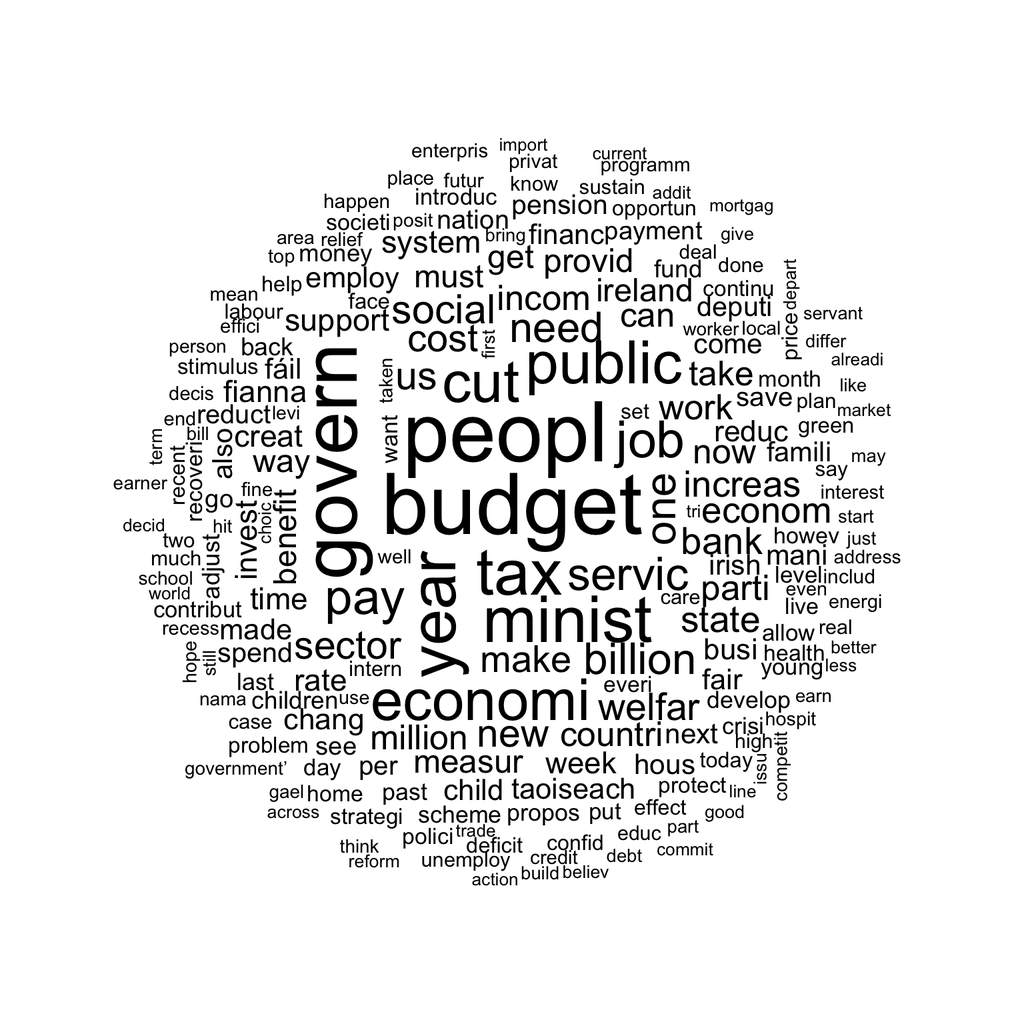

   ```r
   plot(ieDfm, min.freq=25, random.order=FALSE)
   ```

   Did you get the same output?
2. Basic string manipulation functions in R

   There are several useful string manipulation functions in the R base library. In addition, we will look at the `stringr` package which provides an additional interface for simple text manipulation.

   The fundamental type (or `mode`) in which R stores text is the character vector. The most simple case is a character vector of length one. The `nchar` function returns the number of characters in a character vector.

   ```r
   require(quanteda)
   s1 <- 'my example text'
   length(s1)
   ```

   ```
   ## [1] 1
   ```

   ```r
   nchar(s1)
   ```

   ```
   ## [1] 15
   ```

   1. Counting characters.

   The `nchar` function is vectorized, meaning that when called on a vector it returns a value for each element of the vector.

   ```r
   s2 <- c('This is', 'my example text.', 'So imaginative.')
   length(s2)
   ```

   ```
   ## [1] 3
   ```

   ```r
   nchar(s2)
   ```

   ```
   ## [1]  7 16 15
   ```

   ```r
   sum(nchar(s2))
   ```

   ```
   ## [1] 38
   ```

   We can use this to answer some simple questions about the inaugural addresses.

   Which were the longest and shortest speeches? We can query this using two functions, `nchar()` and `which.max()` and `which.min()`.

   ```r
   which.max(nchar(inaugTexts))
   ```

   ```
   ## 1841-Harrison
   ##            14
   ```

   ```r
   which.min(nchar(inaugTexts))
   ```

   ```
   ## 1793-Washington
   ##               2
   ```

   2. Extracting characters.

   Unlike in some other programming languages, it is not possible to index into a string in R:

   ```r
   s1 <- 'This file contains many fascinating example sentences.'
   s1[6:9]
   ```

   ```
   ## [1] NA NA NA NA
   ```

   To extract a substring, instead we use the `substr()` function. Using the help page from `?subst`, execute a call to `substr()` to return the characters from `s1` below from the 6th to the 9th characters.

   ```r
   s1 <- 'This file contains many fascinating example sentences.'
   substr(s1, 6, 9)
   ```

   ```
   ## [1] "file"
   ```

   A note for you C programmers: R counts from 1, not 0.
   3. Splitting texts and using lists.

   Often we would like to split character vectors to extract a term of interest. This is possible using the `strsplit` function. Consider the names of the inaugural texts:

   ```r
   names(inaugTexts)
   ```

   ```
   ##  [1] "1789-Washington" "1793-Washington" "1797-Adams"
   ##  [4] "1801-Jefferson"  "1805-Jefferson"  "1809-Madison"
   ##  [7] "1813-Madison"    "1817-Monroe"     "1821-Monroe"
   ## [10] "1825-Adams"      "1829-Jackson"    "1833-Jackson"
   ## [13] "1837-VanBuren"   "1841-Harrison"   "1845-Polk"
   ## [16] "1849-Taylor"     "1853-Pierce"     "1857-Buchanan"
   ## [19] "1861-Lincoln"    "1865-Lincoln"    "1869-Grant"
   ## [22] "1873-Grant"      "1877-Hayes"      "1881-Garfield"
   ## [25] "1885-Cleveland"  "1889-Harrison"   "1893-Cleveland"
   ## [28] "1897-McKinley"   "1901-McKinley"   "1905-Roosevelt"
   ## [31] "1909-Taft"       "1913-Wilson"     "1917-Wilson"
   ## [34] "1921-Harding"    "1925-Coolidge"   "1929-Hoover"
   ## [37] "1933-Roosevelt"  "1937-Roosevelt"  "1941-Roosevelt"
   ## [40] "1945-Roosevelt"  "1949-Truman"     "1953-Eisenhower"
   ## [43] "1957-Eisenhower" "1961-Kennedy"    "1965-Johnson"
   ## [46] "1969-Nixon"      "1973-Nixon"      "1977-Carter"
   ## [49] "1981-Reagan"     "1985-Reagan"     "1989-Bush"
   ## [52] "1993-Clinton"    "1997-Clinton"    "2001-Bush"
   ## [55] "2005-Bush"       "2009-Obama"      "2013-Obama"
   ```

   ```r
   # returns a list of parts
   parts <- strsplit(names(inaugTexts), '-')
   years <- sapply(parts, function(x) x[1])
   pres <-  sapply(parts, function(x) x[2])
   ```

   Examine the previous code carefully, as it uses list data types in R, which are something fundamentally important to understand. In **quanteda**, the `tokenizedTexts` class of object – created when you call `tokenize()` on a character object or corpus – is a type of list. Try it:

   ```r
   toks <- tokenize("This is a sentence containing some caractères Français.")
   ```

   Now examine the “structure” of that object – assigned to “`toks`” – using `str()`. What does it indicate?

   Try sending `toks` to the global environment, by simply typing its name in the console and pressing Enter. Can you explain why it looks the way that it does? Hint: You can examine all available “methods” for an object class using the `methods()` function. Try `methods(class = "tokenizedTexts")`, and use the help function `?methods` to explain what you see.
   4. Joining character objects together.

   The `paste` function is used to join character vectors together. The way in which the elements are combined depends on the values of the `sep` and `collapse` arguments:

   ```r
   paste('one','two','three')
   ```

   ```
   ## [1] "one two three"
   ```

   ```r
   paste('one','two','three', sep='_')
   ```

   ```
   ## [1] "one_two_three"
   ```

   ```r
   paste(years, pres, sep='-')
   ```

   ```
   ##  [1] "1789-Washington" "1793-Washington" "1797-Adams"
   ##  [4] "1801-Jefferson"  "1805-Jefferson"  "1809-Madison"
   ##  [7] "1813-Madison"    "1817-Monroe"     "1821-Monroe"
   ## [10] "1825-Adams"      "1829-Jackson"    "1833-Jackson"
   ## [13] "1837-VanBuren"   "1841-Harrison"   "1845-Polk"
   ## [16] "1849-Taylor"     "1853-Pierce"     "1857-Buchanan"
   ## [19] "1861-Lincoln"    "1865-Lincoln"    "1869-Grant"
   ## [22] "1873-Grant"      "1877-Hayes"      "1881-Garfield"
   ## [25] "1885-Cleveland"  "1889-Harrison"   "1893-Cleveland"
   ## [28] "1897-McKinley"   "1901-McKinley"   "1905-Roosevelt"
   ## [31] "1909-Taft"       "1913-Wilson"     "1917-Wilson"
   ## [34] "1921-Harding"    "1925-Coolidge"   "1929-Hoover"
   ## [37] "1933-Roosevelt"  "1937-Roosevelt"  "1941-Roosevelt"
   ## [40] "1945-Roosevelt"  "1949-Truman"     "1953-Eisenhower"
   ## [43] "1957-Eisenhower" "1961-Kennedy"    "1965-Johnson"
   ## [46] "1969-Nixon"      "1973-Nixon"      "1977-Carter"
   ## [49] "1981-Reagan"     "1985-Reagan"     "1989-Bush"
   ## [52] "1993-Clinton"    "1997-Clinton"    "2001-Bush"
   ## [55] "2005-Bush"       "2009-Obama"      "2013-Obama"
   ```

   5. Manipulating case

   `tolower` and `toupper` change the case of character objects:

   ```r
   tolower(s1)
   ```

   ```
   ## [1] "this file contains many fascinating example sentences."
   ```

   ```r
   toupper(s1)
   ```

   ```
   ## [1] "THIS FILE CONTAINS MANY FASCINATING EXAMPLE SENTENCES."
   ```

   These are also examples of “vectorized” functions: They work on vectors of objects, rather than just atomic objects. Try these functions on the character vectors below:

   ```r
   sVec <- c("Quanteda is the Best Text Package Ever, approved by NATO!",
             "Quanteda является лучший текст пакет тех, утвержденной НАТО!")
   ```

   Try running `tolower()` on that vector. What results?

   **quanteda** has its own, smarter lowercase function, called `toLower()`. Try it on `sVec`. There is an option to preserve the acronym – try it a second time while preserving the acronym `NATO` as uppercase. To find out how, read the fine manual (RTFM): ?toLower.
3. Counting and comparing objects.
   1. Comparing character objects.

   Charcter vectors can be compared using the `==` and `%in%` operators:

   ```r
   tolower(s1) == toupper(s1)
   ```

   ```
   ## [1] FALSE
   ```

   ```r
   'apples'=='oranges'
   ```

   ```
   ## [1] FALSE
   ```

   ```r
   tolower(s1) == tolower(s1)
   ```

   ```
   ## [1] TRUE
   ```

   ```r
   'pears' == 'pears'
   ```

   ```
   ## [1] TRUE
   ```

   ```r
   c1 <- c('apples', 'oranges', 'pears')
   'pears' %in% c1
   ```

   ```
   ## [1] TRUE
   ```

   ```r
   c2 <- c('bananas', 'pears')
   c2 %in% c1
   ```

   ```
   ## [1] FALSE  TRUE
   ```

   Try using this with the `length()` function to figure out how many times `new` occurs in the tokenized text of the 57th inaugural speech, which you can access as a **quanteda** built-in object as `inaugTexts[57]`. Hint: use `%in%` to return a logical vector, and coerce this to 0s and 1s by using the `sum()` function on the resulting vector.
   2. Pattern matching

   The base functions for searching and replacing within text are similar to familiar commands from the other text manipulation environments, `grep` and `gsub`. The `grep` manual page provides an overview of these functions.

   The `grep` command tests whether a pattern occurs within a string:

   ```r
   grep('orange', 'these are oranges')
   ```

   ```
   ## [1] 1
   ```

   ```r
   grep('pear', 'these are oranges')
   ```

   ```
   ## integer(0)
   ```

   ```r
   grep('orange', c('apples', 'oranges', 'pears'))
   ```

   ```
   ## [1] 2
   ```

   ```r
   grep('pears', c('apples', 'oranges', 'pears'))
   ```

   ```
   ## [1] 3
   ```

   The `gsub` command substitutes one pattern for another within a string:

   ```r
   gsub('oranges', 'apples', 'these are oranges')
   ```

   ```
   ## [1] "these are apples"
   ```

4. Making a corpus and corpus structure
   1. From a vector of texts already in memory.

      The simplest way to create a corpus is to use a vector of texts already present in R’s global environment. Some text and corpus objects are built into the package, for example `inaugTexts` is the UTF-8 encoded set of 57 presidential inaugural addresses. Try using `corpus()` on this set of texts to create a corpus.

      Once you have constructed this corpus, use the `summary()` method to see a brief description of the corpus. The names of the character vector `inaugTexts` should have become the document names.
   2. From a directory of text files.

      There are many other ways to create a corpus, most using the intermediate function `textfile()` to read texts into R. Explore these ways by studying `?textfile`. Can you reproduce the examples?

      No you probably cannot, since many of them refer to files that are local to my system.

      ```r
      # mytf <- textfile("~/Dropbox/QUANTESS/corpora/home_office_animals/txts/*.txt", encoding = "UTF-8")
      mytf <- textfile("~/Dropbox/QUANTESS/corpora/amicus/all/*.txt")
      mycorpus <- corpus(mytf)
      summary(mycorpus, 5)
      ```

      ```
      ## Corpus consisting of 102 documents, showing 5 documents.
      ##
      ##       Text Types Tokens Sentences
      ##  sAP01.txt  1825   7935       256
      ##  sAP02.txt  2131   8629       393
      ##  sAP03.txt  2200  10241       475
      ##  sAP04.txt  1377   6253       232
      ##  sAP05.txt  2227   9345       372
      ##
      ## Source:  /Users/kbenoit/Dropbox/Classes/ICL/Text Analysis 2016/Exercises/Exercise 1/* on x86_64 by kbenoit
      ## Created: Tue Mar  8 11:19:25 2016
      ## Notes:
      ```